# Lecture 03: Expressions

Associated Textbook Sections: [3.0, 3.1, 3.2, 3.3](https://ccsf-math-108.github.io/textbook/chapters/03/programming-in-python.html).

## Overview

- Python
- Jupyter Notebooks
- Expressions
- Names
- Function Calls
- Errors and Exceptions

## Python

### Python 3.11

- Python is popular both for data science & general software development
- Mastering the language fundamentals is critical
- Learn through practice, not by reading or listening
- Follow along with the lecture notebook posted on the Canvas Lecture pages.
  - The lecture templates notebooks show the code partially completed, and I'll complete those during the lecture.
  - You can follow along with your own copy of the notebook to help the lectures feel more interactive and to get more practice with the language.

#### Check Version

See the version of Python installed on this system.

```python
!python --version
```

```
Python 3.11.9
```

## Jupyter Notebooks

### What are Notebooks?

- [Jupyter Notebooks](https://jupyter-notebook.readthedocs.io/) are web applications
- Some things you can do with notebooks:
  - develop and run computer-interpreted code
  - engage with and produce human-focused documentation
  - support reproducible science
  - and more!
- In this class:
  - Open notebooks from links provided in Canvas (default)
  - The links are important because they update the notebooks if we make changes

### Jupyter Notebook Interface (Version 7)

[figure not shown]

- Notebook Name:
  - The name displayed at the top of the page, next to the Jupyter logo, reflects the name of the .ipynb file.
  - Clicking on the notebook name brings up a dialog that allows you to rename it.
- Menu Bar: The menu bar presents different options that may be used to manipulate the way the notebook functions.
- Toolbar: The toolbar gives a quick way of performing the most-used operations within the notebook, by clicking on an icon.

### Notebook Cells

You'll learn a lot about notebooks throughout the semester, but the main building block of a notebook is called a cell.

There are two basic types of cells:

- Code cells
- Markdown (text) cells

#### A Code Cell

- Code cells interpret computer code.
- Our notebooks support the Python programming langauge.

```python
# This is a code cell that prints out the text Hello, MATH 108!

print('Hello, MATH 108!')
```

```
Hello, MATH 108!
```

#### A Markdown Cell

- All the formatted text is contained in a Markdown cell.
- You can double-click these cells to edit them.
- Markdown is a markup language that allows you to type as if you were using a basic text editor, but you have a few formatting features such as:
  - **bold**,
  - *italic*,
  - etc.
- There is a straightforward [Markdown guide](https://www.markdownguide.org/basic-syntax/) that shows you how to do all the basic formatting.

### Kernel

- Computational process that runs the code in the notebook
- The kernel status appears in the upper right of the notebook:
  - Open circle: kernel is ready to run a cell
  - Closed circle: kernel is not ready to run a cell
  - Circle with a lightning bolt along with the phrase 'No Kernel': kernel has shut down for some reason
- A number appears to the left of a code cell showing the order in which the code cells have been run
- If your kernel has shut down:
  - The "memory" of the notebook has been lost
  - You will need to re-run the cells
    - Select `Kernel` -> `Restart` in the Menu Bar
    - Re-run all the cells you want to run

## Expressions

### What are Expressions?

Expressions are combinations of symbols that are interpreted to produce some value.

### Demo: Expressions

Try making a few expressions.

```python
"Hello"
```

```
'Hello'
```

```python
x = 2
```

```python
[2, 4, 5]
```

```
[2, 4, 5]
```

```python
abs(-10)
```

```
10
```

```python
import math
```

### Demo: Arithmetic in Python

Try performing some basic arithmetic with Python

```python
# Addition
2 + 9
```

```
11
```

```python
# Multiplication
2 * 9
```

```
18
```

```python
# Division
2 / 9
```

```
0.2222222222222222
```

```python
# Exponentiation
2 ** 4
```

```
16
```

```python
# Modulo
4 % 2
```

```
0
```

### Order of Operation

- Python follows an order of operations when you combine operations in one expression
- The order for arithmetic is similar to the order from Math class
- Use parentheses to influence the order

### Demo: Order of Operation

Use parentheses to influence the value for the following expression.

```python
# The original expression evaluates to 29
2 + 3 * 9
```

```
29
```

```python
# Use parentheses to make the expression evaluate to 45
(2 + 3) * 9
```

```
45
```

## Names

### Assignment Statements

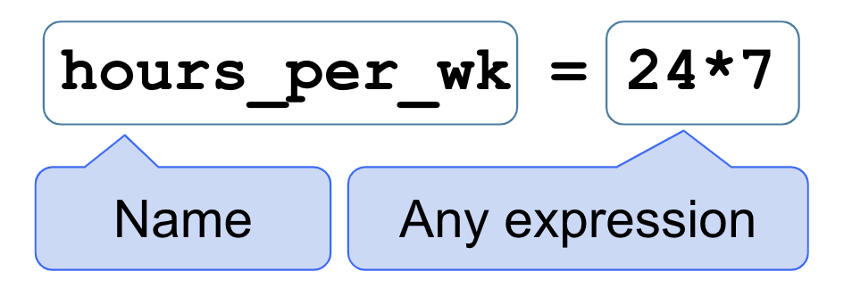

- Statements perform an action
- An assignment statement changes the meaning of the name to the left of the = symbol
- The name is bound to a value (not an equation)

### Demo: Names

- Define a few names
- Apply them to create arithmetic operations
- Differentiate between names and strings.

```python
a = 4
```

```python
a
```

```
4
```

```python
a * 3
```

```
12
```

```python
b = 9
b
```

```
9
```

```python
total = a + b
total
```

```
13
```

```python
a = 10
```

```python
total
```

```
13
```

```python
total = a + b
total
```

```
19
```

```python
"total"
```

```
'total'
```

### Demo: Why Names?

- See how helpful choices of names can help you and others navigate your code.
- Notice that you can get the same numbers from arithmetic, but it can be hard to tell what the code refers to.

```python
hours_per_week = 40
weeks_per_year = 52
```

```python
hours_per_year = hours_per_week * weeks_per_year
hours_per_year
```

```
2080
```

```python
# Minimum wage for businesses w/26 or more employees as of 2024
ca_hourly_minimum_wage = 16.00
```

```python
weekly_wages = hours_per_week * ca_hourly_minimum_wage
weekly_wages
```

```
640.0
```

```python
yearly_wages = hours_per_year * ca_hourly_minimum_wage
yearly_wages
```

```
33280.0
```

```python
40 * 16.00
```

```
640.0
```

```python
40 * 52 * 16.00
```

```
33280.0
```

## Function Calls

### Anatomy of a Call Expression

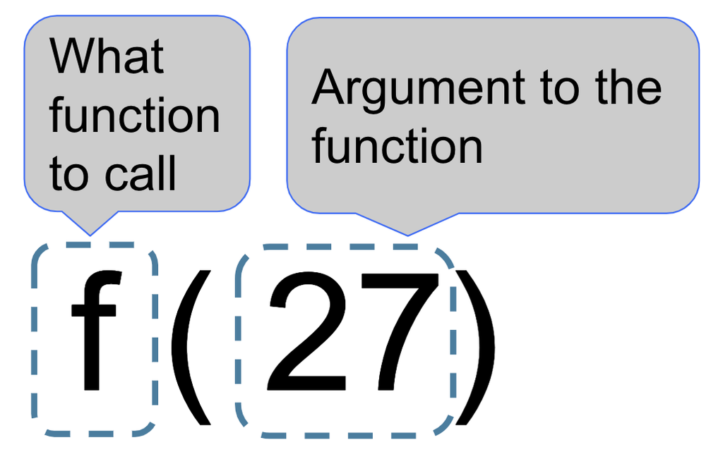

Read: "Call `f` on 27."

### Anatomy of a Call Expression - Multiple Arguments

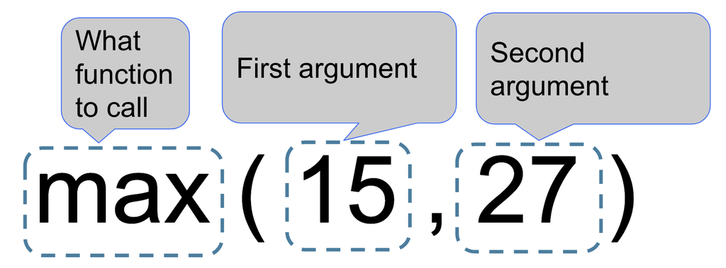

### Demo: Functions and Call Expressions

- Perform function calls with the built-in absolute value function.
- Try using built-in functions that accept more than 1 argument.

```python
abs(-5)
```

```
5
```

```python
abs(1 - 3)
```

```
2
```

```python
day_temp = 52
night_temp = 47
abs_diff_in_temps = abs(night_temp - day_temp)
abs_diff_in_temps
```

```
5
```

```python
min(14, 15)
```

```
14
```

```python
round(123.456)
```

```
123
```

### Function Documentation

- Use the `help` function to see information about a function
- Put the `?` in front of a function's name to pull up more detailed documentation in Jupyter.

```python
?round
```

```
Signature: round(number, ndigits=None)
Docstring:
Round a number to a given precision in decimal digits.

The return value is an integer if ndigits is omitted or None.  Otherwise
the return value has the same type as the number.  ndigits may be negative.
Type:      builtin_function_or_method
```

### Demo: Function Documentation

- Explore the documentation for the `round` function.
- Notice that you can explicitly specify argument values, but Python can also know what to do based on the position of the values.

```python
round(123.456, 1)
```

```
123.5
```

```python
round(123.456, ndigits=1)
```

```
123.5
```

## Errors and Exceptions

### Embracing Errors

- Errors happen and that is okay!
- Python provides error messages to help correct errors
- The size of the printout of the error does not correlate to the size of the error
- Try your best to learn the details of these messages to help you debug your errors
- [Python's documentation](https://docs.python.org/3/library/exceptions.html#bltin-exceptions) contains a discription for all the built-in errors messages.

### Syntax Error

- Syntax errors are very common
- The indicate that something is wrong with the format of the code
- The ^ symbol used to *try* and point out where the error might be

```python
# A SyntaxError
display([1, 2, 3]
```

```
  Cell In[39], line 2
    display([1, 2, 3]
                     ^
SyntaxError: incomplete input
```

### Name Error

- This is another common error for this course
- Name errors indicate the name used has not been defined
- If the kernel shuts down and cells need to be re-run this error could show up

```python
# A NameError
print(a_name)
```

```
---------------------------------------------------------------------------
NameError                                 Traceback (most recent call last)
Cell In[40], line 2
      1 # A NameError
----> 2 print(a_name)

NameError: name 'a_name' is not defined
```

## Attribution

This content is licensed under the Creative Commons Attribution-NonCommercial-ShareAlike 4.0 International License (CC BY-NC-SA 4.0) and derived from the Data 8: The Foundations of Data Science offered by the University of California, Berkeley.